[figure not shown]

# ‘Deweathering’ air quality data

Author

David Carslaw and Jack Davison

Published

December 14, 2022

Abstract

Recent advances in statistical techniques opens up the possibility to analyse air quality data in a range of powerful ways. One of these techniques that has emerged as a useful and practical tool is to *deweather* air quality trends with applications such as considering the impact of interventions. R packages exist to allow users to carry out sophisticated analysis of air quality and other atmospheric data.

# 1 What is de-weathering?

## 1.1 Introduction

Concentrations of air quality pollutants in the atmosphere are affected by a wide range of factors. Arguably, the two most important factors are related to emission strength and meteorology.

Meteorology affects the concentrations of air pollutants across a very wide range of time scales — from seconds to years. When considering changes in the concentrations of pollutants in the atmosphere, it is very difficult to know how much of the variation is due to changes in emissions or the effect of meteorology. This is an especially important issue when considering trends in pollutant concentrations. Trends can easily be masked or emphasised due to meteorology, making it difficult or impossible to know whether policies aimed at reducing concentrations have been effective.

Additionally, in air pollution analysis, we are often interested to know whether a specific planned or unplanned intervention has had the executed effect, and to quantify the effect. Planned interventions are those such as low emission or clean air zones. By far the most important unplanned intervention is that due to Covid-19, which resulted in drastic changes in activities, which in turn affected emissions.

In assessing the sorts of effects mentioned above, life would be easier if we had the same weather every day! That way, a decrease in concentrations of a pollutant from one day to the next, or one year to the next, could be firmly attributed to a decrease in emissions. In a country such as the UK, the weather is far from constant from one day to the next or one year to the next, making the weather a critical consideration to account for in the analysis of air pollution data.

It is however possible to analyse air pollution data in a way that ‘accounts’ for changes in meteorology. These techniques are often referred to as **meteorological normalisation** or **de-weathering** (Grange and Carslaw 2019). The idea behind these techniques is actually quite simple: if you can build a model to explain pollutant concentrations in terms of meteorological variables, then it should be possible to predict what the concentrations would be under fixed or average meteorological conditions (Carslaw and Taylor 2009). These techniques have also been used for interventions such as the short-term closure of an airport (Carslaw, Williams, and Barratt 2012) and the impacts of Covid-19 across Europe (Grange et al. 2021).

Grange, Stuart K., and David C. Carslaw. 2019. “Using Meteorological Normalisation to Detect Interventions in Air Quality Time Series.” *Science of The Total Environment* 653 (February): 578–88. https://doi.org/10.1016/j.scitotenv.2018.10.344.

Carslaw, David C., and Paul J. Taylor. 2009. “Analysis of Air Pollution Data at a Mixed Source Location Using Boosted Regression Trees.” *Atmospheric Environment* 43 (22-23): 3563–70. https://doi.org/10.1016/j.atmosenv.2009.04.001.

Carslaw, David C., Martin L. Williams, and Ben Barratt. 2012. “A Short-Term Intervention Study Impact of Airport Closure Due to the Eruption of Eyjafjallajökull on Near-Field Air Quality.” *Atmospheric Environment* 54 (July): 328–36. https://doi.org/10.1016/j.atmosenv.2012.02.020.

Grange, Stuart K., James D. Lee, Will S. Drysdale, Alastair C. Lewis, Christoph Hueglin, Lukas Emmenegger, and David C. Carslaw. 2021. “COVID-19 Lockdowns Highlight a Risk of Increasing Ozone Pollution in European Urban Areas.” *Atmospheric Chemistry and Physics* 21 (5): 4169–85. https://doi.org/10.5194/acp-21-4169-2021.

So how can a model be built to explain air pollutant concentrations? In the past, this sort of problem would likely have been solved using a technique such as multiple regression, where concentrations would be explained in terms of variables such as wind speed, wind direction, ambient temperature etc. However, in practice, it is very difficult to build good models in this way because the problem itself is fundamentally complex. The challenges include (for example) that concentrations do not vary linearly with variables such as wind speed and wind direction, and that each of these variables does not act totally independently from another. For example, the variation in the concentration of a pollutant with wind speed almost certainly depends on wind direction. It’s complex because the underlying processes of atmospheric physics and chemistry are complex!

In recent years there have been some exciting progress made in statistical modelling related to a vast new range of approaches in the field of **machine learning (ML)**. This has led to the development of many new and powerful techniques that make use of growing data sets to improve the predictive capabilities of models. These methods include approaches such as **Random Forests** and **Boosted Regression Trees** — and many variants of them. These techniques work best when large data sets are available so that the models can ‘learn’ from the data itself and explain the underlying patterns and relationships that exist. In the air pollution field we benefit from having large amounts of data (which we often don’t appreciate).

## 1.2 Regression trees

The main methods that will be discussed related to meteorological normalisation are related to *decision trees*, or more specifically, *regression trees*, which are a well-established statistical modelling approach. It is worth spending a moment to think about how they work in principle and how they might be useful.

As an example, concentrations of hourly NO<sub>x</sub> have been considered at a background site in central London and a predictive model developed that aims to predict NO<sub>x</sub> in terms of different variables:

- *ws*, wind speed
- *wd*, wind direction (degrees)
- *air_temp*, ambient air temperature
- *hour,* hour of the day
- *weekday*, categorical day of the week.

The example is for illustration rather than a serious attempt to predict NO<sub>x</sub> concentrations. However, note from the above list of variables there is a mix of numeric and categorical, which regression trees can handle. The modelling has been carried out using the rpart R package. **The output from the model, shown in Figure 1, will be discussed during the training.**

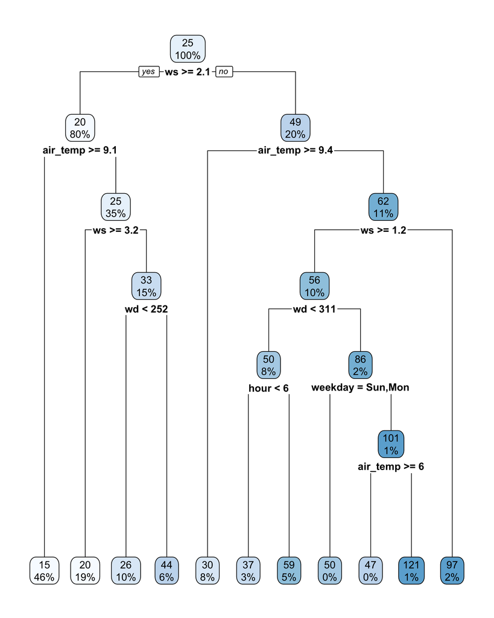

Figure 1: A standard regression tree prediction of NO<sub>x</sub> concentrations at a London background site. The model expressed NO<sub>x</sub> as a function of wind speed (ws), wind direction (wd), ambient temperature (air_temp), hour of day and day of the week (as a categorical variable).

**The advantages of regression tree approaches**

The developments over the past decade in computer and statistical science have provided many powerful approaches for modelling complex data. Regression tree approaches are used in many applications — so what makes them so useful for air quality problems? A summary of some of the advantages is given below, partly based on Elith, Leathwick, and Hastie (2008).

Elith, J., J. R. Leathwick, and T. Hastie. 2008. “A Working Guide to Boosted Regression Trees.” *Journal of Animal Ecology* 77 (4): 802–13. https://doi.org/10.1111/j.1365-2656.2008.01390.x.

- Boosted regression trees combine the strengths of two algorithms: regression trees (models that relate a response to their predictors by recursive binary splits) and boosting (an adaptive method for combining many simple models to give improved predictive performance)
- Boosted regression trees (BRT) incorporate important advantages of tree-based methods such as handling different types of predictor variables e.g. categorical and continuous. They can fit complex nonlinear relationships, and automatically handle interaction effects between predictors, which are very important in atmospheric science. Moreover, for intervention analysis they can capture both abrupt and gradual changes.
- Although BRT models are complex, they can be summarised in ways that give powerful atmospheric science insight, and their predictive performance is superior to most traditional modelling methods; sometimes vastly so.
- They are of course fully implemented in R such as the Greenwell et al. (2022) (gbm) package.

Greenwell, Brandon, Bradley Boehmke, Jay Cunningham, and GBM Developers. 2022. “Gbm: Generalized Boosted Regression Models.” https://CRAN.R-project.org/package=gbm.

While the details of ML techniques are complex, at their heart they are still predictive models — regression on steroids! What makes these approaches so powerful? In the case of air pollution, it is strongly related to the factors mentioned above: relationships between variables are complex and non-linear and there are a very wider range of complex interactions between variables, together with having enough data available to build good models: the very problems that ML can deal with.

There are two principal R packages that can be used to de-weather air quality data: rmweather (which uses a Random Forests approach) and deweather (which uses a Boosted Regression Trees approach). The two packages use similar approaches related to regression trees and tend to give similar results in practice. The former is available on CRAN and can be installed in the same way as any other R package, whereas `deweather` is available on GitHub and can be installed by[^1]:

```r
devtools::install_github("davidcarslaw/deweather")
```

The packages we need for this session are loaded below, with comments.

```r
library(openair) # to access AQ data
library(worldmet) # for measured met data
library(deweather) # to deweather AQ data
library(tidyverse) # packages to manipulate / join data
```

# 2 Example data and approach

## 2.1 AQ and meteorological data

As an introduction to de-weathering, we will work with two years of data from Marylebone Road. The steps involved are:

- Import 2-years of data from Marylebone Road using `importAURN`
- Import 2-years of meteorological data using [worldmet](https://davidcarslaw.github.io/worldmet/index.html)
- Join the AQ and met data — but don’t use modelled met data that is imported by `importAURN`

```r
my1 <- importAURN(site = "my1", year = 2019:2020)
met <- worldmet::importNOAA(year = 2019:2020) # defaults to Heathrow met

# join data sets but drop ws, wd, air_temp from importAURN
aq <- left_join(select(my1, -ws, -wd, -air_temp),
                met,
                by = "date")
```

**Explore the data**

It is always important to explore the data you are working on, even if you think you know it already. Which variables are available, what are their values and summary statistics look like? [openair](https://davidcarslaw.github.io/openair/) can be used effectively in this respect e.g. wind roses, time series plots etc.

## 2.2 Build your first model

It is easy enough to build a model to test and use. In this example we will use the `deweather` package as an example. There are a couple of functions available to test and build models:

- `testMod` to test a model based on user-chosen inputs.
- `buildMod` to build a `deweather` model based on user-chosen inputs

It should be noted that Boosted Regression Trees as implemented in R (the gbm package) has lots of different options for tuning and refining models. The `deweather` package tries to simplify the process by choosing sensible defaults based on testing with many different data sets.

First, to test a model, here is an example:

```
[1] "Percent increase in RMSE using test data is 1.6%"
```

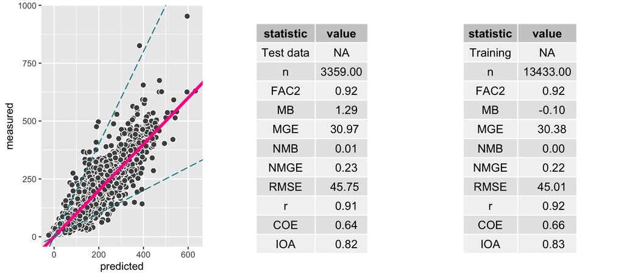

Figure 2: Output statistics for a deweather model. The model performance is given for two sets of data: the ‘training’ data used to develop the model (right-hand table) and data withheld from model development (‘test’ data, shown in the left table). The plot shows the test data predictions against observations.

```r
testMod(aq,
  vars = c("trend", "ws", "wd", "air_temp", "hour", "weekday"),
  pollutant = "nox"
)
```

So, what were the variables chosen and why? First, the ‘trend’ is a variable representing the overall trend of the data, which we eventually want to extract and work with. Second, we choose some obvious meteorological variables known to affect local NO<sub>x</sub> concentrations (wind speed, wind direction and ambient temperature). Third, we include other temporal variables ‘hour’ and ‘weekday’. The purpose of the other variables is that they represent changes by hour of the day and day of the week that are not associated with meteorological variation — **these variables are mostly present to account for variation in emissions that can vary by hour of the day and day of the week**. The `testMod` function can be used to test different models quickly to gain an overall idea of their explanatory power.

When a testing model is developed, by default a random 20% of the data is not used — it is withheld. The developed model is then evaluated against the withheld data to see how well it performs. This approach is central to most machine learning models because they are generally used in situations where a lot of data is available. Such an approach is also powerful in that the model is tested on independent data not used to make the model in the first place.

When running `testMod` the increase in the RMSE in going from training to test data is printed to the screen as a percentage. Reasonable values of an increase in RMSE would be a few percent. If the increase is large — say around 10%, it would be indicative of model over-fitting. This means the model is not very general: it works well on the training data but performs much worse on test data. A way to deal with this is to reduce the number of trees used to fit the model. The default of 200 tends to work quite well for hourly data but may be too high for daily data, for example. Reducing the trees (`n.trees` as an option to the function) to 100 or even 50 would help tackle this issue.

However, there are no hard and fast rules as to what reasonable values of these metrics should be — it depends on the situation and the amount of information available; hence, some experimentation is used to get a feel for how model performance changes with variable choice and model complexity.

**What variables to use in a model?**

Most practical models tend to use a very similar set of input variables. For local air quality problems, wind speed, wind direction and ambient temperature can explain a **very** large amount of the variation in pollutant concentrations. Other variables such as atmospheric pressure and relative humidity can also be useful in some situations. However, there tends to be rapidly diminishing returns from adding more variables, even if they are available. In general it is better to use fewer variables to allow for the more effective interpretation of models.

Temporal variations used to capture potential emissions variation like hour of the day and day of the week are very useful, although hour of the day is unnecessary with daily average data. For longer term data sets spanning many years, day of the year can be useful to capture seasonal variations. The variable `jday` (Julian day, or day of the year) can be used for this purpose.

To build a model, use can be made of the `buildMod` function, for example:

```r
nox_mod <- buildMod(aq,
  vars = c("trend", "ws", "wd", "air_temp", "hour", "weekday"),
  pollutant = "nox",
  n.core = 6
)
```

In this case the option `n.core` is useful to use multiple processors (cores) to speed the calculations up. These models can take a few minutes to run. For longer term data that spans several years it can be a good idea to work with daily average data e.g. use `timeAverage` first to produce a data frame of daily averages before use in a model.

## 2.3 Exploring the model output

Having built a model, it is very useful to explore the main outputs because they provide a lot of insight into the behaviours of air pollution. The principal output is a series of *partial dependency* plots. In simple terms, these plots show the dependence of the pollutant in question against a particular model variable, *while holding other variables at a constant level*. This makes it easier to see the independent effect of different variables and how concentrations of the pollutant in question vary depending on them.

These plots are useful to explore and think about from an air quality perspective. Do the variations make sense from a physical and chemical perspective?

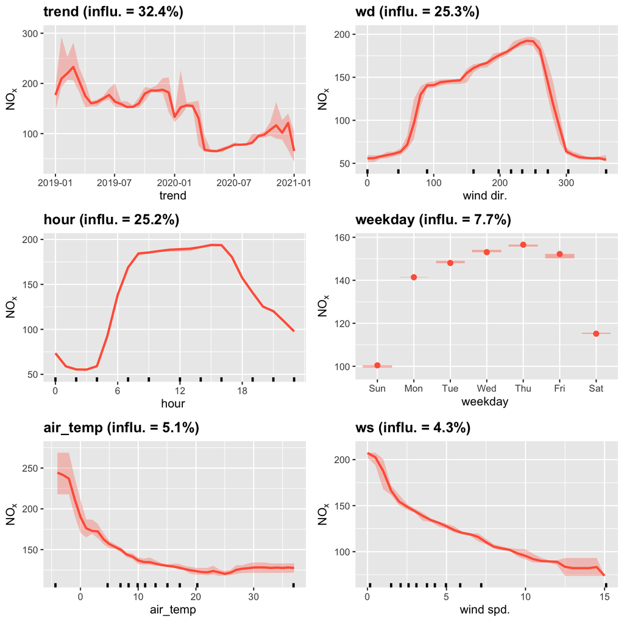

Figure 3: Partial dependence plot for concentrations of NO<sub>x</sub> and Marylebone Road.

```r
plotAllPD(nox_mod)
```

So, what does Figure 3 show? Quite a few things …

- First, the plots are ordered from most important to least important variables in terms of explaining NO<sub>x</sub> concentrations, shown by the ‘Influence’ score. On this basis, the trend component is most important.
- Wind direction is the next most important with concentrations peaking at about 250°.
- Hour of the day shows the very common behaviour related to the diurnal change in emissions following typical road traffic sources. There is also a clear day of the week influence.
- Ambient temperature and wind speed behave in similar ways in that low temperatures and wind speeds tend to result in the highest concentrations of NO<sub>x</sub>. This is also typically what is seen and is related to stable atmospheres and how emissions disperse.

**Try a background site**

It is worth building a model for a background site such as North Kensington (code = ‘kc1’). In this case it is useful to consider the effect of meteorological variables, which can be more prominent in these models. Check out the hour of the day influence using `plotAllPD` and compare that with the raw data diurnal variation by using `timeVariation` on the raw data — what are the differences and what is the explanation?

Each element shown in Figure 3 can be plotted individually. So, to get a better view of the trend for example:

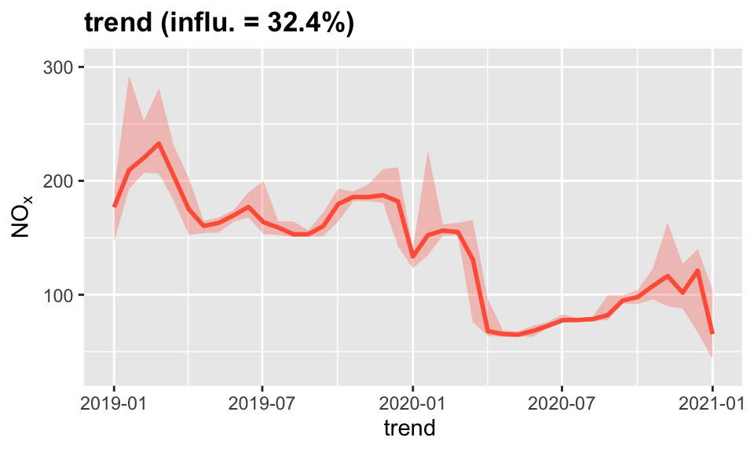

Figure 4: Partial dependence plot for concentrations of NO<sub>x</sub> and Marylebone Road for the trend component.

```r
plotPD(nox_mod, variable = "trend")
```

The results shown in Figure 4 are the quickest way of getting an idea of a de-weathered trend, calculated by holding other variables constant. Figure 4 shows a clear decrease in NO<sub>x</sub> concentrations at the start of the Covid-19 lockdown in March 2020.

We can also explore how pairs of variables are related to one another using the `plot2Way` function. For example, to investigate the joint effect of wind speed and ambient temperature:

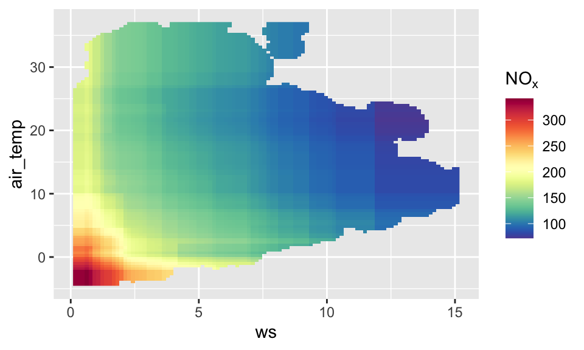

Figure 5: A two-way partial dependence plot for concentrations of NO<sub>x</sub> and Marylebone Road for wind speed and ambient temperature.

```r
plot2Way(nox_mod, variable = c("ws", "air_temp"))
```

What does Figure 5 show? It represents the relationship that NO<sub>x</sub> has with wind speed and ambient temperature while holding all other variables at a constant level. What is clear from Figure 5 is that the highest NO<sub>x</sub> concentrations occur under conditions of low wind speed and low ambient temperature. This makes sense from an atmospheric perspective for this type of source in an urban area where the highest concentrations tend to occur under stable atmospheric conditions.

## 2.4 Meteorologically-averaged trends

The trend shown in Figure 4 gives a good idea of the variation in NO<sub>x</sub> while holding meteorology constant. A more comprehensive approach would be to randomly sample the weather conditions from the original data and run the model hundreds of times and then average the results i.e. a ‘meteorologically averaged’ trend. This can be done using the `metSim` function. the function takes arguments of which variables to randomly sample, which typically would be all the non-trend components.

```r
avg_trend <- metSim(nox_mod,
  metVars = c("ws", "wd", "air_temp", "hour", "weekday")
)
```

Now we can plot a meteorologically averaged trend.

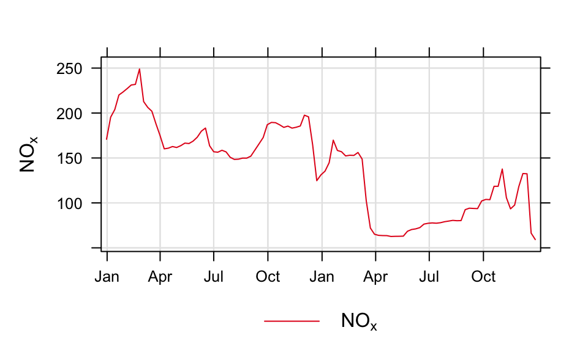

Figure 6: Meteorologically averaged trend of NO<sub>x</sub> concentrations.

```r
timePlot(avg_trend, pollutant = "nox", avg.time = "week")
```

**Try with sampling a few different variables**

In Figure 6 all the variables given by the `metVars` option were sampled. If you wanted to get an idea of the influence of a single variable on the trend (for example wind speed), then choosing `metVars = "ws"` would only randomly sample wind speed and leave all other variables as their measured values — try a few different options …

# 3 Effect of meteorological year

One of the potentially many applications of this way of analysing data is to determine whether air pollutant concentrations for a particular year were ‘good’ or ‘bad’ due to the weather.

## 3.1 Use of meteorological normalisation

Meteorological data from London from 2010 to 2020 have been considered together with concentrations from an urban background site in 2019. The question addressed is: *how much would the concentrations measured in 2019 change if the meteorology from other years was experienced?*

To do this, we can first read in the met data, which is available in the data directory of the course on-line directory, assumed to be in the Downloads directory. There are a series of steps involved with this analysis:

- Combine air quality and meteorological data for 2019 at an urban background site in London.
- Build a `deweather` model to explain concentrations of NO<sub>2</sub>.
- Write a function that takes a meteorological year of interest and predict NO<sub>2</sub> for that year.
- Plot the results and order the year that is associated with the lowest NO<sub>2</sub> to the highest NO<sub>2</sub> concentration.

```r
met <- readRDS("~/Downloads/london_met_2010_2020.rds")
```

Next we import some air quality data for 2019.

```r
# remove modelled met variables because we use measured
aq <- importAURN(site = "kc1", year = 2019) %>%
  select(-ws, -wd, -air_temp)
```

```r
# basic meteorological year analysis
library(deweather)
library(openair)
library(worldmet)
library(tidyverse)

# join AQ and met data
aq <- left_join(aq, met, by = "date")

# build model
mod_aq <- buildMod(aq,
  vars = c(
    "ws", "wd", "air_temp", "hour",
    "week", "weekday", "trend"
  ),
  pollutant = "no2", B = 1, n.trees = 200
)

# function to calculate new annual mean concentration
calc_conc_year <- function(met_year, aq, met, mod_aq) {

  met_select <- selectByDate(met, year = met_year) %>%
    select(ws, wd, air_temp)

  # AQ and met may not have exactly same rows
  n_data <- min(c(nrow(aq), nrow(met_select)))

  new_aq <- slice(aq, 1:n_data) %>%
    select(-ws, -wd, -air_temp)

  new_met <- slice(met_select, 1:n_data)

  new_data <- bind_cols(new_aq, new_met) %>%
    prepData() # this adds variables such as hour, weekday, ...

  # predict concentrations using the model
  pred <- gbm::predict.gbm(mod_aq$model, new_data, n.trees = 200)

  results <- tibble(
    met_year = as.character(met_year),
    no2 = mean(pred, na.rm = TRUE)
  )

  return(results)
}

# run the function for met years 2010, ..., 2020
results <- map_df(2010:2020, calc_conc_year, aq, met, mod_aq)
```

Now we can plot the results, with the additional step of ordering the results from low to high using the `reorder` function. Overall, the NO<sub>2</sub> concentration varies by about 3.5 μg m<sup>-3</sup> (compared with a mean of 26 μg m<sup>-3</sup>) depending on the weather year in question (2015 being the lowest and 2010 the highest).

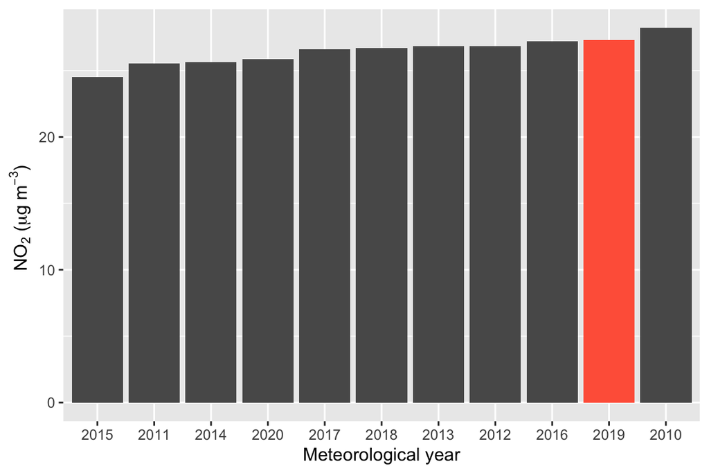

Figure 7: Effect of meteorological year on 2019 NO<sub>2</sub> concentrations using the deweather method.

```r
ggplot(results, aes(reorder(met_year, no2), no2)) +
    geom_bar(stat = "identity") +
    geom_bar(
        data = filter(results, met_year == "2019"),
        aes(met_year, no2),
        fill = "tomato", stat = "identity"
    ) +
  xlab("Meteorological year") +
  ylab(quickText("no2 (ug/m3)"))
```

## 3.2 Poor man’s meteorological normalisation

The analysis above provides a sophisticated way to understand the effect of ‘meteorological year’ on concentrations of pollutants. However, there are simpler analyses that can be carried out in R too that might be useful. One approach is to bin the wind speed and wind direction and calculate the frequency of measurements and associated mean concentration of a pollutant. Different years will have different frequencies of wind speed and direction that will influence the associated overall concentration.

This is an example of using R’s capability to enhance the sort of analysis that can be carried out for air quality problems. We’ll go through the code in the training session.

```r
# what to round ws and wd to
ws_int <- 1
wd_int <- 10

# frequency summary of AQ data
aq_summary <- select(aq, ws, wd, no2) %>%
  mutate(
    ws = round(ws / ws_int) * ws_int,
    wd = round(wd / wd_int) * wd_int
  ) %>%
  group_by(ws, wd) %>%
  summarise(
    no2 = mean(no2, na.rm = TRUE),
    n = n()
  )

# function to re-calculate frequencies
new_year_av <- function(year = 2020) {

  # select met year
  met_data <- filter(met, lubridate::year(date) == year)

  # get frequencies
  met_data <- mutate(met_data,
    ws = round(ws / ws_int) * ws_int,
    wd = round(wd / wd_int) * wd_int
  ) %>%
    group_by(ws, wd) %>%
    tally()

  # apply to AQ data
  aq_met <- inner_join(select(aq_summary, -n),
    met_data,
    by = c("ws", "wd")
  ) %>%
    mutate(f_n = n * no2) %>%
    ungroup() %>%
    na.omit() %>%
    summarise(met_year = as.character(year), no2 = sum(f_n / sum(n)))

  return(aq_met)
}

simple_results <- map_dfr(2010:2020, new_year_av)
```

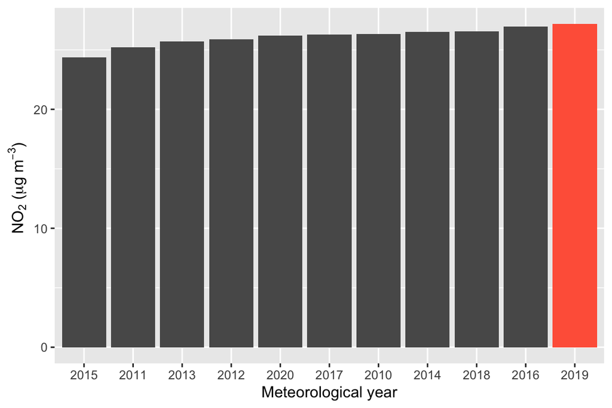

Figure 8: Effect of meteorological year on 2019 NO<sub>2</sub> concentrations using the simple frequency method.

```r
ggplot(simple_results, aes(reorder(met_year, no2), no2)) +
  geom_bar(stat = "identity") +
  geom_bar(
    data = filter(simple_results, met_year == "2019"),
    aes(met_year, no2),
    fill = "tomato", stat = "identity"
  ) +
  xlab("Meteorological year") +
  ylab(quickText("no2 (ug/m3)"))
```

As a final step, we can see how the two approaches compare, which is shown in Figure 9.

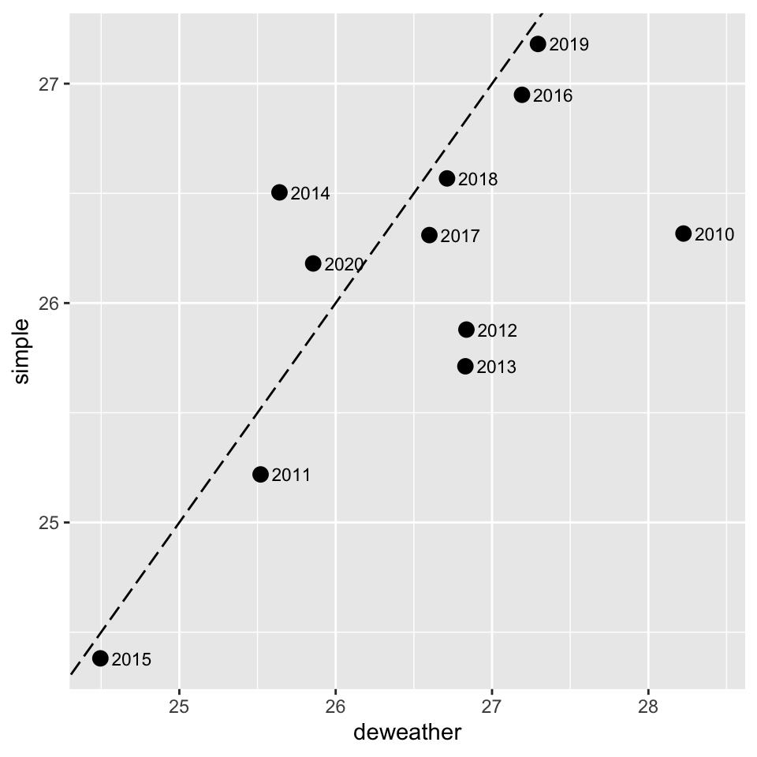

Figure 9: Comparison of influence of meteorological year on concentrations of NO<sub>2</sub> using the deweather and simple frequency methods. The dashed line is the 1:1 line.

```r
all_results <- tibble(met_year = results$met_year,
                      deweather = results$no2,
                      simple = simple_results$no2)

ggplot(all_results, aes(deweather, simple)) +
  geom_point(size = 3) +
  theme(aspect.ratio = 1) +
  geom_text(aes(deweather + 0.2, simple, label = met_year), size = 3) +
  geom_abline(slope = 1, linetype = 5)
```

## Footnotes

[^1]: You might need to install the `devtools` package first if that is not available.`